# ‘Do women find men more attractive in conjuction with the colour red?’: A replication of Elliot et al.’s study (2010)

*N* removed NAs: 3

*N* removed typo: 1

*N* removed <18: 24

*N* total clean: 122

| Group | *N* | *M*<sub>age</sub> | *M*<sub>rating</sub> |
| --- | --- | --- | --- |
| Control | 58 | 21.0 | 6.72 |
| Experim | 64 | 21.4 | 5.59 |

**Main analysis results**

*t*(120) = 7.37, *p* < .001

[interactive chart not shown]

[figure not shown]

[interactive chart not shown]

# ‘Do women find men more attractive in conjuction with the colour red?’: A replication of Elliot et al.’s study (2010)

Analysing Data, Spring 2020

This student has a record of specific learning difficulty (dyslexia/dyspraxia). Please mark this report in accordance with the [marking guidelines for SLD](https://www.sussex.ac.uk/studentsupport/staff/spld?fbclid=IwAR2lYKD6xvuv9egQDvG8d_oed9GUD3KXQn3gAdlHZ1gQB8gDddBdeOEmKdE).

# Methods

## Participants

The original number of people who participated in the experiment was 150. After cleaning the data, the mean number of participants’ ages in total as shown in table 1 is 21.2 and the standard deviation is 2.16, suggesting little variation in age. However, in the separate conditions (table 2) the data was slightly different. In the control group the mean was 21 and the standard deviation was 2.09 and in the experimental group the mean age was 21.5 and the standard deviation was 2.20. In total, 28 participants were removed. 1 participant’s data was removed because there was a typo in the age variable, it proved to not be useful because the age could not be determined. Another 3 participants were removed because of n/a, not enough or relevant data was collected. Lastly 24 participants were removed because they were of an unethical age, which was below 18, participants need to be 18 to take part. The final number of people whose data was included in the results was 122 and the ages of participants ranged from 18 years old to 26 years old.

```r
table1
```

```
## # A tibble: 1 x 4
##   mean_age sd_age min_age max_age
##      <dbl>  <dbl>   <dbl>   <dbl>
## 1     21.2   2.16      18      26
```

```r
table2
```

```
## # A tibble: 2 x 4
##   GROUP            n mean_age sd_age
##   <fct>        <int>    <dbl>  <dbl>
## 1 control         58     21     2.09
## 2 experimental    64     21.5   2.20
```

## Design

In this experiment I tested whether women find men more attractive in conjunction with the colour red. This is a replication of Elliot et al.’s study (Elliot et al., 2010) on whether red influences women’s attraction to men. The independent variables in this experiment are the two conditions, experimental and control. In the experimental condition, the participants (n = 64) were shown a black and white photo of a man in a red background for 5 seconds. The control condition is the same however the participants (n = 58) were presented with a photograph with a white background instead. The photos were created as a 4-inch by 6-inch head and torso shots of a moderately attractive Caucasian white man, it was selected from a standard photo set (Corneille, Monin, & Pleyers, 2005), the colour was placed in the area surrounding the photo. These independent variables are operationalized as a factor. The dependent variable is the rating that the participants give based on their perceptions of the man’s attractiveness. The perceived attractiveness was judged with three face-valid items: “How attractive do you think this person is?”, “How pleasant is this person to look at?” and “If I were to meet the person in this picture face to face, I would think he is attractive.” These items were rated on a 9-point Likert scale ranging from 1, which is ‘not at all attractive’ to 9 which is ‘very attractive’. These scores were averaged to form one composite score. The operational hypothesis is that ‘women will rate the man, using a 9-point Likert scale, in the red condition differently compared to those women in the white condition’. The statistical analysis I used to test this is an independent-groups t-test design.

# Results

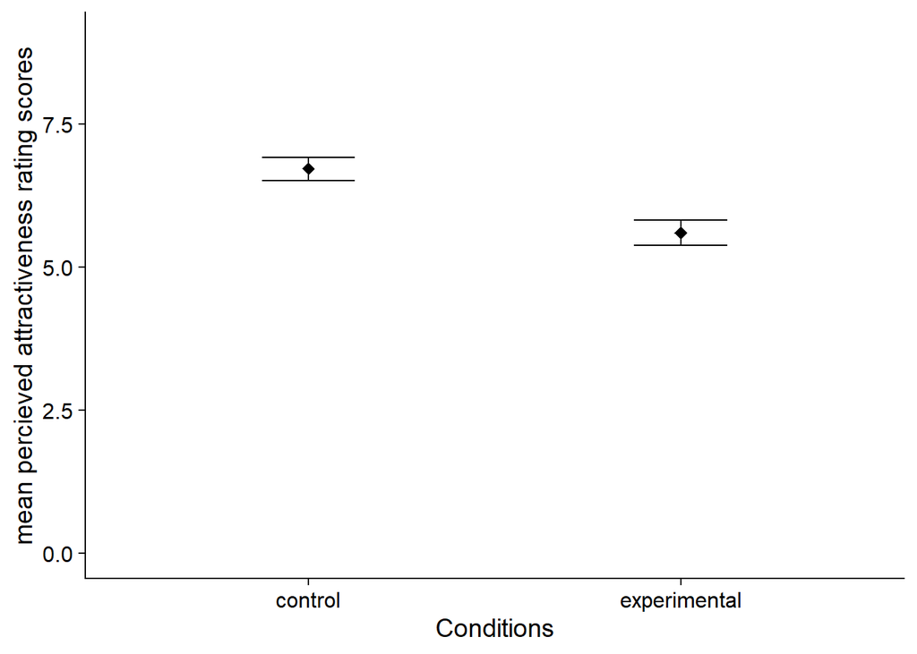

```r
figure_1
```

Figure_1, shows the mean composite score by colour group condition, the two conditions are control (white) and experimental (red). The graph shows that the women in the control condition had a higher mean rating in perceived attractiveness compared to the women in the experimental group. The composite score in the control condition is 6.718391 and the composite score in the experimental group is 5.593750. This suggests that women found the men with a white background more attractive to the women seeing a red background. The signal to noise ratio is relatively large because t = 7.3731, which suggests a big difference in sample means compared to the error.

We investigated whether, as predicted, women would rate the men in the red condition (experimental group) differently to the women in the white condition, based on perceived attractiveness (control group), using an independent-measures *t*-test. This test showed that the means in the two conditions differed (*M*<sub>diff</sub> = 1.12, 95% CI [0.82, 1.43]) and there was a significant difference between the 2 groups on ratings of perceived attractiveness (*t* (120) = 7.37, *p* = < 0.001)

# Discussion

In summary, according to my data that I collected and analysed using a t – test, there was a statistically significant difference between the women’s mean rating scores on perceived attractiveness in the red and white condition, which supports my hypothesis. It was found that women perceived the men in the white condition as more attractive compared to the women in the red condition.

In the original study on ‘Red, Rank and Romance in women viewing men’ by (Elliot et al., 2010), it was reported that there was a significant colour effect in women when rating men’s perceived attractiveness. In my replication of specifically Experiment 1, I discovered the same effect, which was a difference in rating scores between the two conditions. The fact that these results agree with each other strengthens the theory that colour plays an important role in attractiveness. However, the distinctive colour that was described as having a higher effect in Elliot et al.’s study was red, whereas in my own replication of the experiment, a white background was shown to rate higher in perceived attractiveness. In the original study the mean composite rating score for the red condition was 6.79 and the white condition, 5.67. In the replicated study, the score in the white condition was 6.71 whereas in the red was 5.59, clearly suggesting that although a significant difference, red did not have a more significant effect as previously predicted. The replicated study results may imply that Elliot et al.’s theory is not as unfalsifiable. In his study he discusses how from an evolutionary perspective, the colour red, was a core part of survival as red was considered a sign of genetic attractiveness that females were drawn to for the purpose of successful reproduction. For example, in Darwinian theory, an individual with red pigmentations in their face was a sign of good health and prosperity (Rowland & Burriss, 2017). However, this finding can be considered outdated because the evolutionary pressures that were present in those times are not consistent with modern day society and therefore not relevant. Due to my results it is important to consider that red as an ‘attractive’ colour to women may simply be redundant.

This research question is worth investigating further because there is still not a clear-cut answer to the idea that red does/doesn’t affect perceived attractiveness ratings. I believe that further studies should take into account more countries and be made aware of cultural differences, as this theory is likely to not be universal. Although Elliot et al. used participants from 4 countries, not 1, that is still not representative of the world and so cannot make this theory absolute. Moreover, it is clear that past studies have falsely reported a positive effect instead of a null effect, which is a prevalent practice in experimental psychology, what is needed is a discussion to reteach the importance of ethics in this scientific practice.

Ultimately, I have discovered from my replication that although my results displayed a statistically significant difference in perceived attractiveness ratings between the two conditions, supporting my hypothesis, there was no real effect on red increasing attractiveness. I have learned that due to many limitations, in relation to sample size and temporal validity it is hard to establish a clear approach that will include all cultures and withstand the passing of time, so as suggested more studies need to be carried out to include all possible factors contributing to this topic.

# References

Corneille, O., Monin, B., & Pleyers, G. (2005). Is positivity a cue or a response option? Warm glow vs evaluative matching in the familiarity for attractive and not-so-attractive faces. *Journal of Experimental Social Psychology: 41*(4), 431–437. *https://doi.org/10.1016/j.jesp.2004.08.004*

Elliot, A. J., Kayser, D. N., Greitemeyer, T., Lichtenfeld, S., Gramzow, R. H., Maier, M. A., & Liu, H. (2010). *Red, Rank, and Romance in Women Viewing Men. *https://doi.org/10.1037/a0019689**

Elliot, A. J., & Maier, M. A. (2013). The red-attractiveness effect, applying the ioannidis and trikalinos(2007b) test, and the broader scientific context: A reply to francis (2013). *Journal of Experimental Psychology: General, 142*(1), 297–300. *https://doi.org/10.1037/a0029592*

Francis, G. (2013). (No Title). Association, 142 (1), 292–296. https://doi.org/10.1037/a0027923

Hesslinger, V. M., Goldbach, L., & Carbon, C. C. (2015). Men in red: A reexamination of the red-attractiveness effect. *Psychonomic Bulletin and Review, 22*(4), 1142–1148. https://doi.org/10.3758/s13423-015-0866-8.

Rowland, H. M., & Burriss, R. P., Human colour in mate choice and competition. https://doi.org/10.1098/rstb.2016.0350